# One-Sample Comparison

Lee & Wagenmakers Part II. 8.1, p119

cn

2023-04-22

```r
set.seed(12345)

if (!require("pacman", quietly = TRUE)) install.packages("pacman")
pacman::p_load(tidyverse, cowplot, R2jags)
pacman::p_load_gh("RLesur/klippy", "rpruim/CalvinBayes")
klippy::klippy()
```

# 1 Graphic model

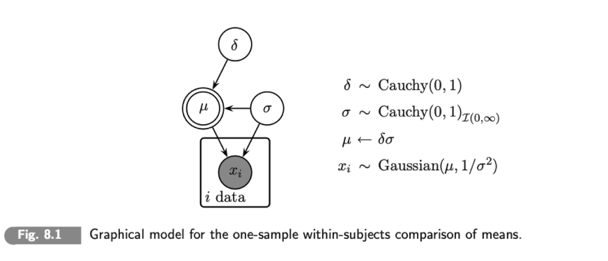

# 2 Model: $H_1: \delta \neq 0$

```r
# Read data Dr. Smith
Winter <- c(-0.05,0.41,0.17,-0.13,0.00,-0.05,0.00,0.17,0.29,0.04,0.21,0.08,0.37,0.17,0.08,-0.04,-0.04,0.04,-0.13,-0.12,0.04,0.21,0.17,
       0.17,0.17,0.33,0.04,0.04,0.04,0.00,0.21,0.13,0.25,-0.05,0.29,0.42,-0.05,0.12,0.04,0.25,0.12)

Summer <- c(0.00,0.38,-0.12,0.12,0.25,0.12,0.13,0.37,0.00,0.50,0.00,0.00,-0.13,-0.37,-0.25,-0.12,0.50,0.25,0.13,0.25,0.25,0.38,0.25,0.12,
      0.00,0.00,0.00,0.00,0.25,0.13,-0.25,-0.38,-0.13,-0.25,0.00,0.00,-0.12,0.25,0.00,0.50,0.00)

x <- Winter-Summer # allowed because it is a within-subjects design
x <- x/sd(x)       # standardize

ndata <- length(Winter) # number of subjects

data  <- list("x", "ndata") # to be passed on to JAGS

myinits <- list(
  list(delta = rnorm(1,0,3), deltaprior = rnorm(1,0,3), sigmatmp = rnorm(1,0,1)),
  list(delta = rnorm(1,0,3), deltaprior = rnorm(1,0,3), sigmatmp = rnorm(1,0,1)),
  list(delta = rnorm(1,0,3), deltaprior = rnorm(1,0,3), sigmatmp = rnorm(1,0,1)))

# Parameters to be monitored
# 교재에는 deltaprior를 표집했지만, 관찰하지 않았다.
parameters <- c("delta", "deltaprior")
```

`JAGS`에는 Cauchy 분포를 위한 함수가 없으므로, $\delta \sim Cauchy(0,1)$을 두 단계 절차로 구현한다.

1. $\delta \sim Gaussian(0,\lambda_\delta)$
2. $\lambda_\delta \sim \chi^2(1)$

```r
model_text <- "
# One-Sample Comparison of Means
model{
  # Data
  for (i in 1:ndata){
    x[i] ~ dnorm(mu,lambda)
  }
  mu <- delta*sigma
  lambda <- pow(sigma,-2)

  # delta and sigma Come From (Half) Cauchy Distributions
  lambdadelta ~ dchisqr(1)
  delta ~ dnorm(0,lambdadelta)
  lambdasigma ~ dchisqr(1)
  sigmatmp ~ dnorm(0,lambdasigma)
  sigma <- abs(sigmatmp)

  # Sampling from Prior Distribution for Delta
  deltaprior ~ dnorm(0,lambdadeltaprior)
  lambdadeltaprior ~ dchisqr(1)
}
"

samples <- jags(data, inits=myinits, parameters,
                model.file = textConnection(model_text),
                n.chains=3, n.iter=10000,
                n.burnin=1000, n.thin=1, DIC=T)
```

```
module glm loaded
```

```r
print(samples)
Inference for Bugs model at "4", fit using jags,
 3 chains, each with 10000 iterations (first 1000 discarded)
 n.sims = 27000 iterations saved
           mu.vect sd.vect    2.5%     25%     50%     75%   97.5%  Rhat n.eff
delta        0.119   0.154  -0.185   0.014   0.120   0.222   0.421 1.001 27000
deltaprior   4.100 497.972 -11.987  -1.012  -0.012   1.009  12.784 1.270 21000
deviance   117.316   1.974 115.392 115.917 116.696 118.064 122.627 1.001  5000

For each parameter, n.eff is a crude measure of effective sample size,
and Rhat is the potential scale reduction factor (at convergence, Rhat=1).

DIC info (using the rule, pD = var(deviance)/2)
pD = 1.9 and DIC = 119.3
DIC is an estimate of expected predictive error (lower deviance is better).

# Collect posterior samples across all chains:
delta.posterior <- samples$BUGSoutput$sims.list$delta
```

## 2.1 Bayes Factor

```r
#============ BFs based on logspline fit ===========================
library(polspline) # this package can be installed from within R
fit.posterior <- logspline(delta.posterior)

# 95% confidence interval:
x0 <- qlogspline(0.025,fit.posterior)
x1 <- qlogspline(0.975,fit.posterior)

posterior <- dlogspline(0, fit.posterior) # this gives the pdf at point delta = 0
prior     <- dcauchy(0)                   # height of order--restricted prior at delta = 0
BFe0      <- posterior/prior # encompassing BF (Moray & Wagenmaker, 2014)'s notation
BFe0
```

```
[1] 6.079499
```

대립가설 $H_1: \delta \neq 0$보다 영가설 $H_0: \delta = 0$이 약 6배 더 증거에 부합한다.

## 2.2 Visualization

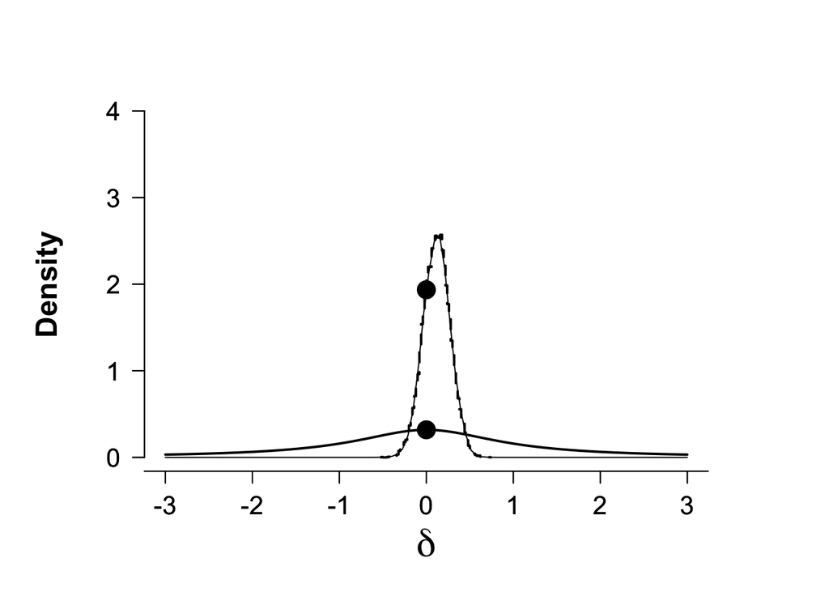

```r
#============ Plot Prior and Posterior  ===========================
par(cex.main = 1.5, mar = c(5, 6, 4, 5) + 0.1, mgp = c(3.5, 1, 0), cex.lab = 1.5,
    font.lab = 2, cex.axis = 1.3, bty = "n", las=1)
xlow  <- -3
xhigh <- 3
yhigh <- 4
Nbreaks <- 80
y       <- hist(delta.posterior, Nbreaks, plot=F)
plot(c(y$breaks, max(y$breaks)), c(0,y$density,0), type="S", lwd=2, lty=2,
     xlim=c(xlow,xhigh), ylim=c(0,yhigh), xlab=" ", ylab="Density", axes=F)
axis(1, at = c(-4,-3,-2,-1,0,1,2,3,4), lab=c("-4","-3","-2","-1","0", "1", "2", "3", "4"))
axis(2)
mtext(expression(delta), side=1, line = 2.8, cex=2)
#now bring in log spline density estimation:
par(new=T)
plot(fit.posterior, ylim=c(0,yhigh), xlim=c(xlow,xhigh), lty=1, lwd=1, axes=F)
points(0, dlogspline(0, fit.posterior),pch=19, cex=2)
# plot the prior:
par(new=T)
plot ( function( x ) dcauchy( x, 0, 1 ), xlow, xhigh, ylim=c(0,yhigh), xlim=c(xlow,xhigh), lwd=2, lty=1, ylab=" ", xlab = " ", axes=F)
axis(1, at = c(-4,-3,-2,-1,0,1,2,3,4), lab=c("-4","-3","-2","-1","0", "1", "2", "3", "4"))
axis(2)
points(0, dcauchy(0), pch=19, cex=2)
```

위에서 posterior와 달리, prior 분포는 MCMC 표본이 아니다. `deltaprior`를 MCMC 표집했는데, 왜 사용하지 않았을까? 그 이유를 살펴보자.

```r
# plot delta
p1 <- posterior(samples)
# head(p1)
# tail(p1)
# plot_post(p1$delta, xlab = expression(delta), quietly = TRUE)
# plot_post(p1$deltaprior, xlim = c(-3, 3), quietly = TRUE)
range(p1$deltaprior)
```

```
[1] -3202.05 79017.28
```

`deltaprior`의 MCMC 표본이 너무 넓은 범위에 분포하기 때문인 것 같다.

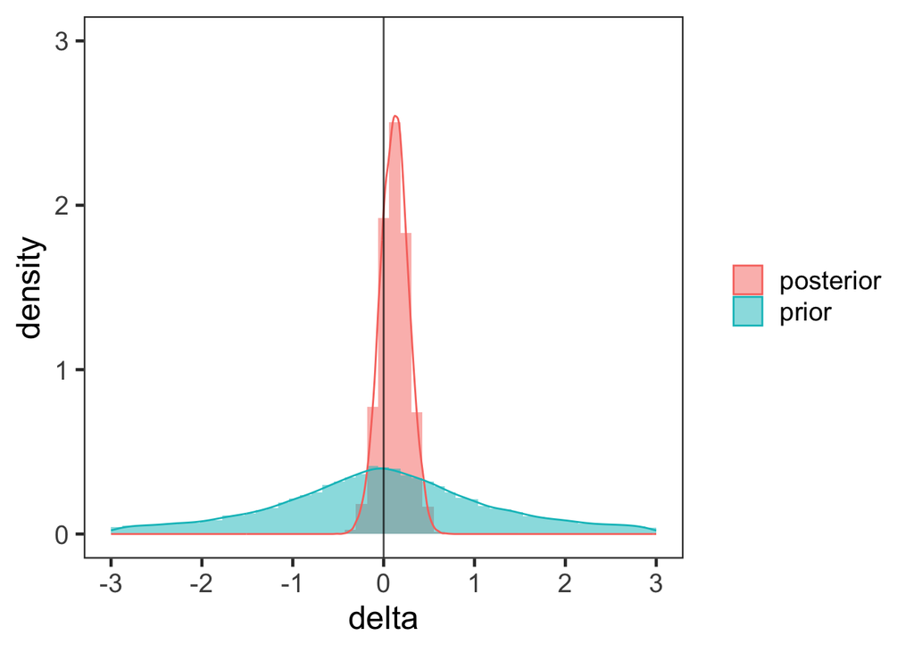

```r
p1 %>% select(delta, deltaprior) %>%
  rename(prior = deltaprior, posterior = delta) %>%
  pivot_longer(cols = everything(), names_to = "samples", values_to = "delta") %>%
  ggplot(aes(x = delta, y= after_stat(density), fill = samples)) +
  scale_y_continuous(breaks = seq(0, 4, 1), limits = c(0, 3)) +
  scale_x_continuous(breaks = seq(-4, 4, 1), limits = c(-3, 3)) +
  geom_histogram(position = "identity", alpha = 0.5, bins = 50) +
  geom_density(aes(color = samples), fill = NA) +
  geom_vline(xintercept = 0, alpha = 0.7) +
  theme_bw(base_size = 18) +
  theme(panel.grid.major = element_blank(),
        panel.grid.minor = element_blank(),
        legend.title = element_blank())
```

`deltaprior`의 범위가 광범위하면 영점의 밀도가 0에 가까와지므로 BF01 추정치가 과장되지 않을까? `polspline` 패키지를 사용하여 (교재 방식 대로) BF01을 다시 계산해보자.

```r
# 먼저 posterior
fit.posterior <- logspline(p1$delta)
posterior0 <- dlogspline(0, fit.posterior) # posterior 영점 밀도

# 다음, prior
# fit.prior <- logspline(p1$deltaprior) # 이게 fit 안된다. 너무 범위가 넓다.

# 위 그림처럼 (-3, 3)까지만 해보자. Censored 자료로 취급하여 bound를 설정했다.
fit.prior <- logspline(p1$deltaprior[p1$deltaprior>-3 & p1$deltaprior<3],
                       lbound = -3, ubound = 3) # 이건 된다.
prior0 <- dlogspline(0, fit.prior)
posterior0/prior0
[1] 4.851459

# 이번에는 (-500, 500)
fit.prior <- logspline(p1$deltaprior[p1$deltaprior>-500 & p1$deltaprior<500],
                       lbound = -500, ubound = 500)
prior0 <- dlogspline(0, fit.prior)
posterior0/prior0
[1] 5.969271
```

예상과 달리, prior 범위를 넓게 해도 BF01은 크게 달라지지 않았다. 그러나 다음 분석을 보자.

# 3 `dt(mu, tau, 1)`

Cauchy 분포는 $t(1)$ 분포이며(`dt(mu, tau, 1)`), 양쪽 꼬리가 두터운 가우시안 분포를 닮았다([여기 참조](https://stackoverflow.com/questions/34935606/cauchy-prior-in-jags)). Gelman은 **non-informative Cauchy prior**로서 `dt(0, pow(2.5,-2), 1)`을 사용하도록 제안한 바 있다.

```r
myinits2 <- list(
  list(delta = rnorm(1,0,3)),
  list(delta = rnorm(1,0,3)),
  list(delta = rnorm(1,0,3)))

model_text2 <- "
# One-Sample Comparison of Means
model{
  # Data
  for (i in 1:ndata){
    x[i] ~ dnorm(mu,lambda)
  }
  mu <- delta*sigma
  lambda <- pow(sigma,-2)

  # delta and sigma Come From (Half) Cauchy Distributions
  delta ~ dt(0, pow(2.5,-2), 1)
  sigma ~ dt(0, pow(2.5,-2), 1)T(0,)

  # Sampling from Prior Distribution for Delta
  deltaprior ~ dt(0, pow(2.5,-2), 1)
}
"

samples2 <- jags(data, inits=myinits2, parameters,
                model.file = textConnection(model_text2),
                n.chains=3, n.iter=10000,
                n.burnin=1000, n.thin=1, DIC=T)
```

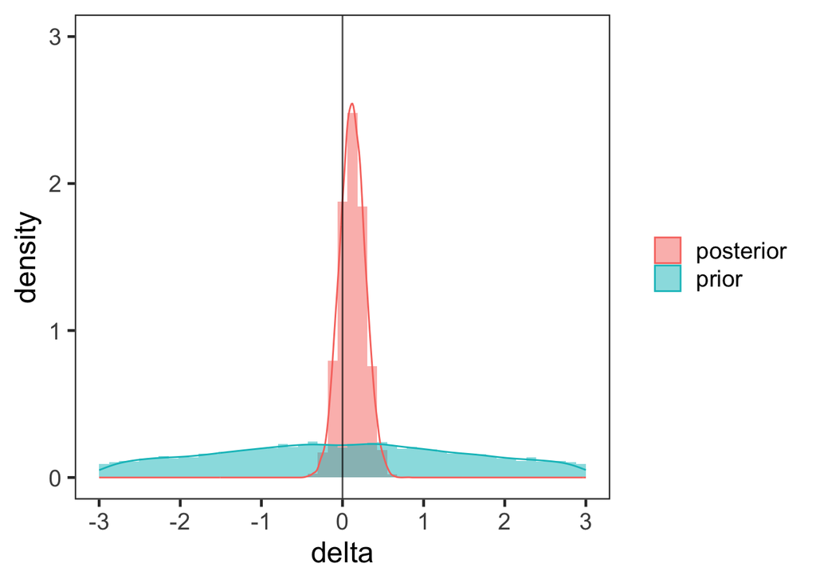

```r
print(samples2)
Inference for Bugs model at "5", fit using jags,
 3 chains, each with 10000 iterations (first 1000 discarded)
 n.sims = 27000 iterations saved
           mu.vect sd.vect    2.5%     25%     50%     75%   97.5%  Rhat n.eff
delta        0.121   0.157  -0.182   0.015   0.120   0.226   0.430 1.001 25000
deltaprior  -4.347 916.364 -31.358  -2.537  -0.044   2.449  32.265 1.235 22000
deviance   117.368   2.028 115.391 115.930 116.746 118.137 122.781 1.001 27000

For each parameter, n.eff is a crude measure of effective sample size,
and Rhat is the potential scale reduction factor (at convergence, Rhat=1).

DIC info (using the rule, pD = var(deviance)/2)
pD = 2.1 and DIC = 119.4
DIC is an estimate of expected predictive error (lower deviance is better).

p2 <- posterior(samples2)
p2 %>%
  select(delta, deltaprior) %>%
  rename(prior = deltaprior, posterior = delta) %>%
  pivot_longer(cols = everything(), names_to = "samples", values_to = "delta") %>%
  ggplot(aes(x = delta, y= after_stat(density), fill = samples)) +
  scale_y_continuous(breaks = seq(0, 4, 1), limits = c(0, 3)) +
  scale_x_continuous(breaks = seq(-4, 4, 1), limits = c(-3, 3)) +
  geom_histogram(position = "identity", alpha = 0.5, bins = 50) +
  geom_density(aes(color = samples), fill = NA) +
  geom_vline(xintercept = 0, alpha = 0.7) +
  theme_bw(base_size = 18) +
  theme(panel.grid.major = element_blank(),
        panel.grid.minor = element_blank(),
        legend.title = element_blank())
```

**non-informative Cauchy prior**라는 점이 그림에서 확실하게 보인다.

```r
# BF를 계산하자. 먼저, posterior의 영점 밀도;
fit.posterior <- logspline(p2$delta)
posterior0 <- dlogspline(0, fit.posterior)

# 다음, prior의 영점밀도; 앞에서처럼 (-3, 3)까지만 해보자.
fit.prior <- logspline(p2$deltaprior[p2$deltaprior>-3 & p2$deltaprior<3],
                       lbound = -3, ubound = 3)
prior0 <- dlogspline(0, fit.prior)
posterior0/prior0
[1] 8.212291

# 앞에서와 달리 (-300, 300)도 수렴 안된다. prior 밀도가 너무 낮다.
# fit.prior <- logspline(p1$deltaprior[p2$deltaprior>-300 & p2$deltaprior<300],
#                        lbound = -300, ubound = 300)
```

prior의 영점밀도가 상대적으로 낮았기 때문에 BF01이 커졌다!

이 상황은 **Jeffreys-Lindley-Bartlett paradox**의 사례인 듯 싶다. [Morey](https://easystats.github.io/bayestestR/reference/bayesfactor_restricted.html)에 따르면, 대립가설의 prior가 넓으면 영가설의 likelihood가 증가하게 되어 영가설이 대립가설보다 무제한으로 지지를 받게될 수 있다. 따라서 언제나 **informed prior**를 써야한다는 의미이다.

# 4 Exercise 8.1.3

아래 그림에서 점선은 정규분포, 실선은 Cauchy 분포이다. 정규분포의 영점 주변 밀도가 더 높다.

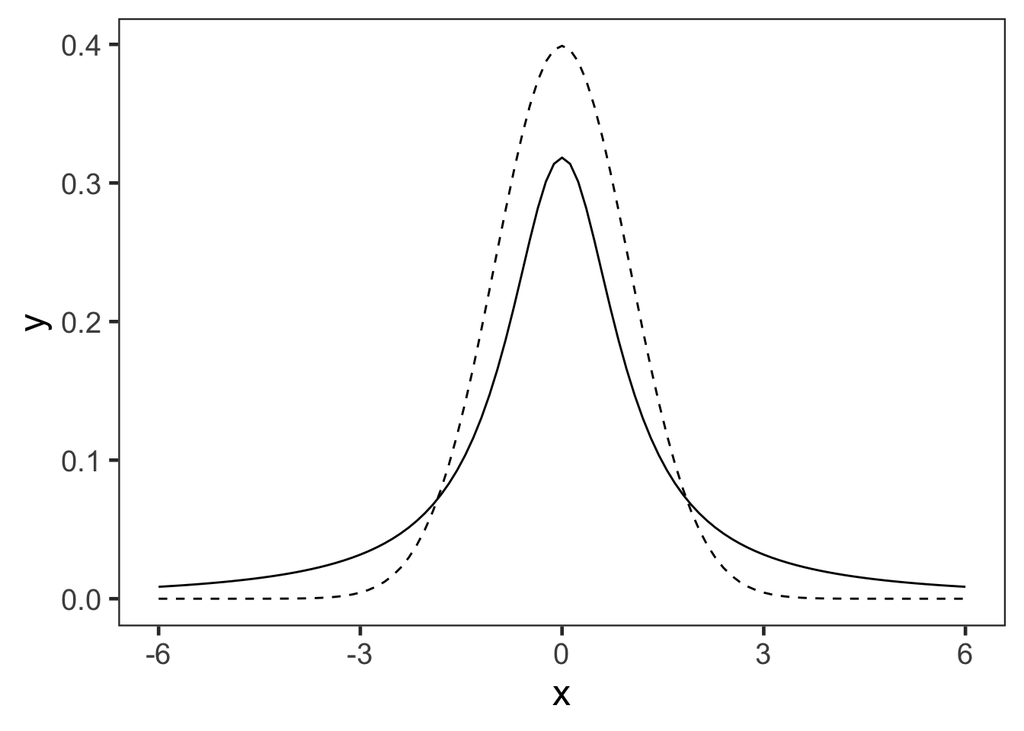

```r
ggplot(data = data.frame(x = c(-6, 6)), aes(x)) +
  stat_function(fun = dnorm, args = list(mean = 0, sd = 1), linetype = 2) +
  stat_function(fun = dcauchy, args = list(location = 0, scale = 1)) +
  theme_bw(base_size = 18) +
  theme(panel.grid.major = element_blank(),
        panel.grid.minor = element_blank(),
        legend.title = element_blank())
```

# 5 Exercise 8.2.3

다음 장의 연습문제이다. Order-restricted 가설($H_2: \delta < 0$)을 검증하기 위해 0보다 큰 MCMC 표본을 제거하고 BF를 계산해도 괜찮은가?

```r
# 0보다 큰 posterior MCMC 표본을 제거한다.
fit.posterior2 <- logspline(p1$delta[p1$delta<0], ubound = 0)
# plot(fit.posterior2)
posterior0 <- dlogspline(0, fit.posterior2)

# 먼저, dcauchy(0)를 두 배한 값으로 BF를 계산하였다.
prior0 <- dcauchy(0)*2
( BF01 <- posterior0/prior0 )
```

```
[1] 15.02345
```

```r
# 다음, 0보다 큰 prior MCMC 표본을 제거하고 BF를 계산하였다.
fit.prior2 <- logspline(p1$deltaprior[p1$deltaprior>-100 & p1$deltaprior<0],
                        lbound = -100, ubound = 0)
# plot(fit.prior2)
prior0 <- dlogspline(0, fit.prior2)
( BF01 <- posterior0/prior0 )
```

```
[1] 14.05483
```

# 6 Exercise 8.2.4

[Morey와 Wagenmakers(2014, Statistics and Probability Letters)](http://www.ejwagenmakers.com/2014/MoreyWagenmakers2014.pdf)에 따르면,
$$B_{r0} \approx
\begin{cases}
(2-p) \times B_{e0}\ , & if\ \delta > 0,\\
p \times B_{e0}\ , & if\ \delta \leq 0
\end{cases}$$
$\delta > 0$는 자료가 **sign-restriction**과 일치하는 경우이다.[^1] 본 사례에서는 $H_3: \delta > 0$에 해당한다([Exercise 8.2.1](https://cogneuro.github.io/lw/ch08/08_2_ModelSelection_OneSampleOrderRestricted.html)).

$\delta \leq 0$는 자료가 **sign-restriction**과 일치하지 않는 경우이다. 본 사례에서는 $H_2: \delta < 0$에 해당한다(다음 [단락](https://cogneuro.github.io/lw/ch08/08_2_ModelSelection_OneSampleOrderRestricted.html)).

```r
t.res <- t.test(x)
t.res$p.value
[1] 0.4364555

# data-consistent, sign-restricted H3 BF: delta > 0
( BF30 <- (2-t.res$p.value)*(1/BFe0) )
[1] 0.2571831

# data-inconsistent, sign-restricted H2 BF: delta < 0
( BF20 <- t.res$p.value*(1/BFe0) )
[1] 0.07179136
```

$BF_{30}$ = 0.26이고 $BF_{03}$ = 3.89이다. $BF_{20}$ = 0.07이고 $BF_{02}$ = 13.93이다. 이 추정치들은 MCMC 표본에서 추정한 BF와 상당히 비슷하다.

# 7 Session Info

```r
sessionInfo()
R version 4.2.3 (2023-03-15)
Platform: aarch64-apple-darwin20 (64-bit)
Running under: macOS Ventura 13.3.1

Matrix products: default
BLAS:   /Library/Frameworks/R.framework/Versions/4.2-arm64/Resources/lib/libRblas.0.dylib
LAPACK: /Library/Frameworks/R.framework/Versions/4.2-arm64/Resources/lib/libRlapack.dylib

locale:
[1] en_US.UTF-8/en_US.UTF-8/en_US.UTF-8/C/en_US.UTF-8/en_US.UTF-8

attached base packages:
[1] stats     graphics  grDevices utils     datasets  methods   base

other attached packages:
 [1] polspline_1.1.22  CalvinBayes_0.2.6 bayesplot_1.10.0  ggformula_0.10.4
 [5] ggridges_0.5.5    scales_1.2.1      ggstance_0.3.6    klippy_0.0.0.9500
 [9] R2jags_0.7-1      rjags_4-13        coda_0.19-4       cowplot_1.1.1
[13] lubridate_1.9.2   forcats_1.0.0     stringr_1.5.0     dplyr_1.1.2
[17] purrr_1.0.1       readr_2.1.4       tidyr_1.3.0       tibble_3.2.1
[21] ggplot2_3.4.2     tidyverse_2.0.0   pacman_0.5.1

loaded via a namespace (and not attached):
  [1] backports_1.4.1      plyr_1.8.8           igraph_1.4.2
  [4] crosstalk_1.2.0      rstantools_2.3.1     inline_0.3.19
  [7] digest_0.6.31        htmltools_0.5.5      magick_2.7.4
 [10] fansi_1.0.4          magrittr_2.0.3       checkmate_2.1.0
 [13] tzdb_0.3.0           mosaicCore_0.9.2.1   brms_2.19.0
 [16] RcppParallel_5.1.7   matrixStats_0.63.0   xts_0.13.1
 [19] timechange_0.2.0     prettyunits_1.1.1    colorspace_2.1-0
 [22] haven_2.5.2          xfun_0.39            callr_3.7.3
 [25] crayon_1.5.2         jsonlite_1.8.4       zoo_1.8-12
 [28] glue_1.6.2           polyclip_1.10-4      gtable_0.3.3
 [31] distributional_0.3.2 pkgbuild_1.4.0       rstan_2.21.8
 [34] abind_1.4-5          mvtnorm_1.1-3        DBI_1.1.3
 [37] miniUI_0.1.1.1       Rcpp_1.0.10          xtable_1.8-4
 [40] stats4_4.2.3         StanHeaders_2.21.0-7 DT_0.27
 [43] htmlwidgets_1.6.2    threejs_0.3.3        posterior_1.4.1
 [46] ellipsis_0.3.2       pkgconfig_2.0.3      loo_2.6.0
 [49] farver_2.1.1         sass_0.4.5           utf8_1.2.3
 [52] labeling_0.4.2       tidyselect_1.2.0     rlang_1.1.0
 [55] reshape2_1.4.4       later_1.3.0          munsell_0.5.0
 [58] tools_4.2.3          cachem_1.0.7         cli_3.6.1
 [61] generics_0.1.3       broom_1.0.4          evaluate_0.20
 [64] fastmap_1.1.1        yaml_2.3.7           processx_3.8.1
 [67] knitr_1.42           tidygraph_1.2.3      nlme_3.1-162
 [70] mime_0.12            compiler_4.2.3       shinythemes_1.2.0
 [73] rstudioapi_0.14      tweenr_2.0.2         bslib_0.4.2
 [76] stringi_1.7.12       highr_0.10           ps_1.7.5
 [79] Brobdingnag_1.2-9    lattice_0.21-8       Matrix_1.5-4
 [82] markdown_1.6         shinyjs_2.1.0        tensorA_0.36.2
 [85] vctrs_0.6.2          pillar_1.9.0         lifecycle_1.0.3
 [88] jquerylib_0.1.4      bridgesampling_1.1-2 httpuv_1.6.9
 [91] R2WinBUGS_2.1-21     R6_2.5.1             promises_1.2.0.1
 [94] gridExtra_2.3        codetools_0.2-19     boot_1.3-28.1
 [97] colourpicker_1.2.0   MASS_7.3-59          gtools_3.9.4
[100] assertthat_0.2.1     withr_2.5.0          ggdag_0.2.8
[103] shinystan_2.6.0      parallel_4.2.3       hms_1.1.3
[106] grid_4.2.3           labelled_2.11.0      rmarkdown_2.21
[109] ggforce_0.4.1        shiny_1.7.4          base64enc_0.1-3
[112] dygraphs_1.1.1.6
```

[^1]: 여기서는 order-restricted와 sign-restricted를 구별하지 않기로 한다.